# SF3B1 iCLIP analysis

Binding site definition

Author

Affiliation

Dr. Mirko Brueggemann

Buchman Institute for Molecular Life Sciences

Published

September 18, 2023

# 1 Analysis Description

This report shows downstream processing of computed binding sites for the *imb_koenig_2016_13_03* dataset. All replicates (3 wt and 2 mut) were down-sampled to the the counts in the lowest mutant replicate and merged for peak calling with PureCLIP. Processed samples are:

- imb_koenig_2016_13_03_wt_2
- imb_koenig_2016_13_03_wt_3
- imb_koenig_2016_13_03_wt_4
- imb_koenig_2016_13_03_mut_1
- imb_koenig_2016_13_03_mut_3 (downsample seed)

## 1.1 Load libraries

```r
library(rtracklayer)
library(GenomicRanges)
library(ggplot2)
library(AnnotationDbi)
library(dplyr)
library(reshape2)
library(UpSetR)
library(GenomicFeatures)
library(kableExtra)
library(knitr)
library(ggrepel)
library(gridExtra)
library(grid)
library(viridis)
library(BindingSiteFinder)
library(ComplexHeatmap)
library(forcats)
library(ggtext)
library(patchwork)
library(tibble)
library(tidyr)
library(dplyr)
library(ggpointdensity)
library(ggsci)
library(ggsci)
library(ggtext)
library(waffle)
library(ggrepel)
library(patchwork)
```

```r
source("../styles.R")
source("../helper.R")
```

# 2 Library downsampling

Due to sequencing depth and library complexity variations, we decided to initially down-sample all replicates to the sample with the overall lowest number of reads (MUT 2). All downstream analysis are performed on the down-sampled data, removing the need of any additional library size normalization.

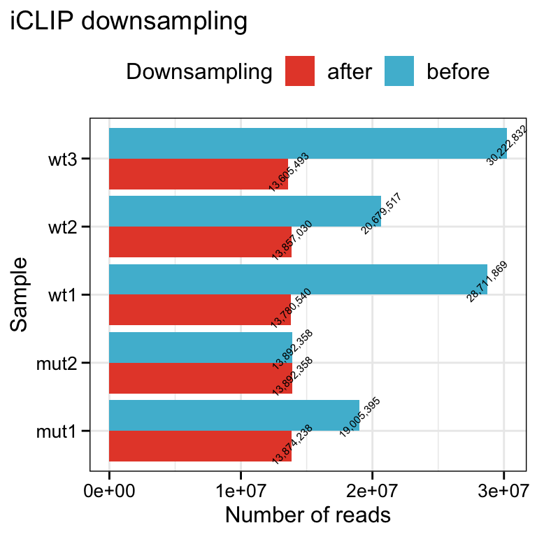

Downsampling of iCLIP samples to the samples with the lowest number of crosslinks.

```r
df = data.frame(
  sample = c("mut1", "mut2", "wt1", "wt2", "wt3"),
  before = c(19005395, 13892358, 28711869, 20679517, 30222832),
  after =  c(13874238, 13892358, 13780540, 13857030, 13605493)
) %>% pivot_longer(-sample)

ggplot(df, aes(x = sample, y = value, fill = name)) +
  geom_col(position = "dodge") +
  theme_nice() +
  coord_flip() +
  scale_fill_npg() +
  theme(legend.position = "top") +
  labs(
    title = "iCLIP downsampling",
    x = "Sample",
    y = "Number of reads",
    fill = "Downsampling"
  ) +
    geom_text(aes(label = myFormat(value)), position = position_dodge(width = 0.8), angle = 45, size = 2)
```

# 3 Gene Annotation

Annotations are downloaded from GENCODE v36 (Release 36 (GRCh38)). Annotations are then filtered by feature and transcript annotation level.

- Feature annotation
  - keep level 1 and 2
  - remove level 3
- Gencode definition
  - 1 = verified loci, 2 = manually annotated loci,3 = automatically annotated loci
- Transcript level annotation
  - keep level 1,2 and 3
  - remove level 4,5 and NA
- Gencode definition
  - 1 (all splice junctions of the transcript are supported by at least one non-suspect mRNA),
  - 2 (the best supporting mRNA is flagged as suspect or the support is from multiple ESTs),
  - 3 (the only support is from a single EST),
  - 4 (the best supporting EST is flagged as suspect),
  - 5 (no single transcript supports the model structure),
  - NA (the transcript was not analyzed)

```r
load("/Users/mirko/Projects/Annotations/human/gencode_36/filtered/gencode_v36_filtered.rda")
anno.db = loadDb("/Users/mirko/Projects/Annotations/human/gencode_36/filtered/gencode_v36_filtered.sqlite")
gns = genes(anno.db)
idx = match(gns$gene_id, anno$gene_id)
elementMetadata(gns) = cbind(elementMetadata(gns), elementMetadata(anno)[idx,])
```

# 4 Preprocess pureCLIP output

Initially peaks are called using PureCLIP as described in the methods section. Here we pre-filter all PureCLIP called crosslink sites to keep only the most informative proportion.

```r
peaksInitial = "/Users/mirko/Projects/sf3b1/01_data_subsamp/combined/pureCLIP/PureCLIP.crosslink_sites_mod.bed"
peaksInitial = import(con = peaksInitial, format = "BED")
```

## 4.1 Gloabal crosslink site filtering

PureClip called crosslink sites are filtered on a global level, removing sites with the lowest 5% PureCLIP score. This essentially removes crosslink sites that are only barely enriched above the local background. These sites likely contribute more noise to the data rather then enhancing the spectrum of detected sites to lowly abundant transcripts, since they are present uniformly across almost all transcripts.

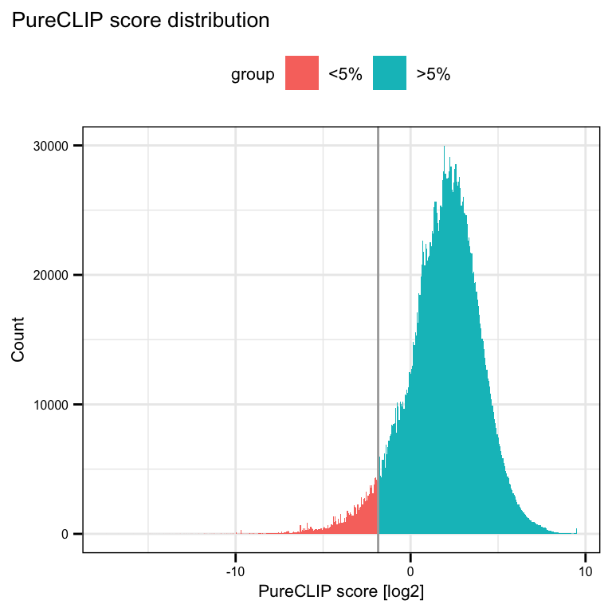

```r
df = data.frame(score = peaksInitial$score)
quantileCutoffpureClipScore = quantile(df$score, probs = seq(0,1, by = 0.05))
peaksFiltered = peaksInitial[peaksInitial$score >= quantileCutoffpureClipScore[2]]

df$group = ifelse(df$score > quantileCutoffpureClipScore[2], ">5%", "<5%")
ggplot(df, aes(x = log2(score), fill = group)) +
    geom_histogram(bins = 500) +
    geom_vline(xintercept = log2(quantileCutoffpureClipScore[2]), color = "darkgrey") +
    labs(
        title = "PureCLIP score distribution",
        x = "PureCLIP score [log2]",
        y = "Count"
    ) +
    theme_pub() +
    theme(legend.position = "top")
```

## 4.2 Gene-level crosslink site filtering

To enrich for the strongest crosslinking pattern only the 20% highest crosslink sites within each transcript were retained for further analysis. This filter is very restrictive, removing a large proportion of the data. It is beneficial for detecting the strongest binding pattern presented in the data.

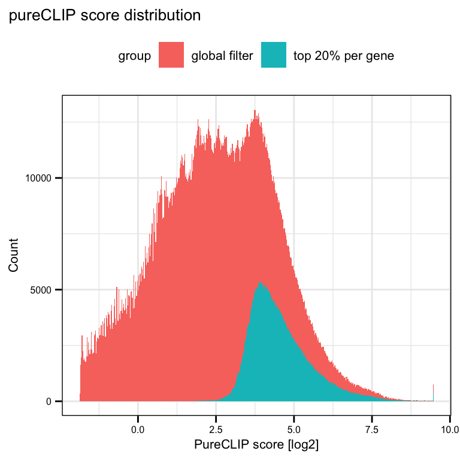

PureCLIP score local filter. Only the top 20% sites per gene are kept.

```r
peaksFilteredPerGene = filterByRegion(gns, peaksFiltered, keepAbove = 0.8)

df1 = data.frame(score = peaksFiltered$score, group = "global filter")
df2 = data.frame(score = peaksFilteredPerGene$score, group = "top 20% per gene")
df = rbind(df1,df2)

ggplot(df, aes(x = log2(score), fill = group)) +
    geom_histogram(bins = 500) +
    xlab("PureCLIP score [log2]") +
    ylab("Count") +
    ggtitle("pureCLIP score distribution") +
    theme_pub() +
    theme(legend.position = "top")
```

# 5 Merge crosslink sites into binding sites

All crosslinks site retained after the above filtering steps are subjected to the iterative binding site resizing routine.

```r
clipFilesWt = "/Users/mirko/Projects/sf3b1/01_data_subsamp/wt/cov/replicate"
clipFilesMut = "/Users/mirko/Projects/sf3b1/01_data_subsamp/mut/cov/replicate"
clipFiles = c(clipFilesWt, clipFilesMut)
clipFiles = list.files(clipFiles, pattern = ".bw$", full.names = TRUE)
clipFilesP = clipFiles[grep(clipFiles, pattern = "Plus")]
clipFilesM = clipFiles[grep(clipFiles, pattern = "Minus")]
# Organize clip data in dataframe
colData = data.frame(
  id = c(1:5),
  condition = factor(c("MUT", "MUT", "WT", "WT", "WT"), levels = c("MUT", "WT")),
                     clPlus = clipFilesP,
                     clMinus = clipFilesM)
# Make BindingSiteFinder object
bds = BSFDataSetFromBigWig(ranges = peaksFilteredPerGene, meta = colData)
```

## 5.1 Binding site width selection

The optimal binding site width is determined by the binding site signal to noise ratio as described in the methods section.

```
[1] "make bs"
[1] "calc ratio"
```

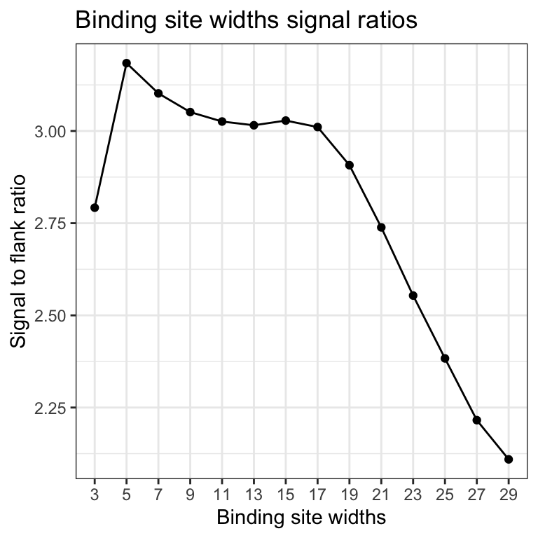

Signal to noise ratio of crosslink events per binding site width. Binding sites are calculated based on the indicated width. The ratio of crosslink events residing within binding sites compared to the sum of crosslink events directly neighbouring the binding site on both sides is computed.

```r
supportRatioPlot(bds,
                 bsWidths = seq(from = 3, to = 29, by = 2),
                 sub.chr = "chr1", minWidth = 2,
                 minClSites = 1, minCrosslinks = 2)
```

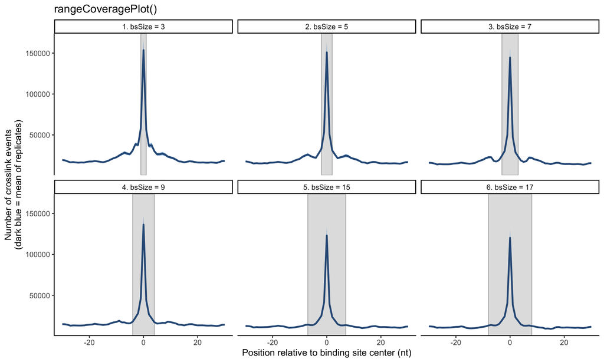

Crosslink profiles of different binding site width options. Binding site and signal are subsetted to chr1.

```r
bds1 <- makeBindingSites(object = bds, bsSize = 3, minWidth = 1,
                              minCrosslinks = 2, minClSites = 1, sub.chr = "chr1")

bds2 <- makeBindingSites(object = bds, bsSize = 5, minWidth = 1,
                              minCrosslinks = 2, minClSites = 1, sub.chr = "chr1")

bds3 <- makeBindingSites(object = bds, bsSize = 7, minWidth = 1,
                              minCrosslinks = 2, minClSites = 1, sub.chr = "chr1")

bds4 <- makeBindingSites(object = bds, bsSize = 9, minWidth = 1,
                              minCrosslinks = 2, minClSites = 1, sub.chr = "chr1")

bds5 <- makeBindingSites(object = bds, bsSize = 15, minWidth = 1,
                              minCrosslinks = 2, minClSites = 1, sub.chr = "chr1")

bds6 <- makeBindingSites(object = bds, bsSize = 17, minWidth = 1,
                              minCrosslinks = 2, minClSites = 1, sub.chr = "chr1")

l = list(`1. bsSize = 3` = bds1, `2. bsSize = 5` = bds2, `3. bsSize = 7` = bds3,
         `4. bsSize = 9` = bds4, `5. bsSize = 15` = bds5, `6. bsSize = 17` = bds6)

rangeCoveragePlot(l, width = 30)
```

## 5.2 Compute binding sites

```r
bsSize_Final = 5
minWidth_Final = 2
minCrosslinks_Final = 2
minClSites_Final = 1
```

Here we use the estimated settings from above to compute equally sized binding site from all input crosslink sites.

- bsSize = 5
- minWidth = 2
- minCrosslinks = 2
- minClSites = 1

```r
bdsMerge <- makeBindingSites(object = bds, bsSize = bsSize_Final, minWidth = minWidth_Final,
                        minCrosslinks = minCrosslinks_Final, minClSites = minClSites_Final)
peaksProcessed = getRanges(bdsMerge)

df = getSummary(bdsMerge)
df = format(df, big.mark = ",", decimal.mark = ".")
kable(df, "latex", caption = "Merge and combine", booktabs = TRUE)
```

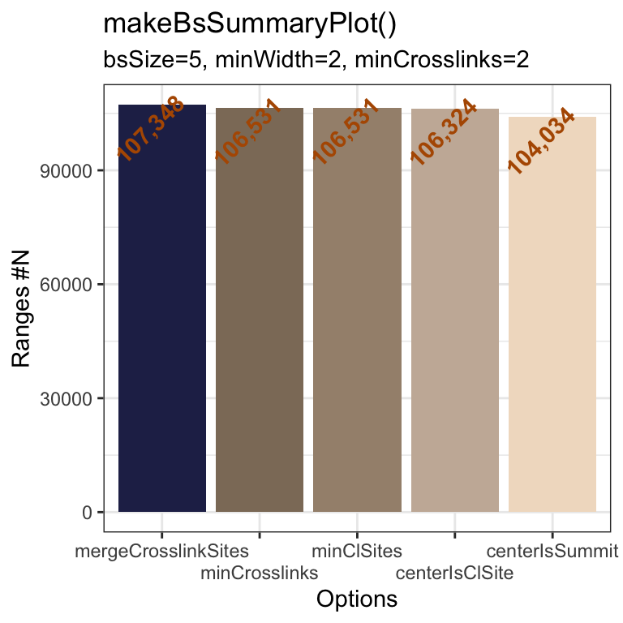

Details of the binding site merging.

```r
makeBsSummaryPlot(bdsMerge) +
    scale_x_discrete(guide = guide_axis(n.dodge = 2))
```

# 6 Replicate reproducibility

Since the initially used crosslink sites are computed from the merged signal of all replicates, binding sites resulting from the previous merge might not be reproducible among all replicates. For that reason, we specifically check which of the computed binding sites are reproduced by the individual replicates.

All crosslink events within each binding site are summed up per replicate. The individual threshold for each replicate is set to the 5% quantile of the crosslink distribution. To account for low cross-link replicates, a lower boundary of a minimum of 2 crosslink events per binding site is enforced. For each binding site all replicate from each condition must meet the defined threshold.

```r
bdsMerge = reproducibilityFilter(bdsMerge, cutoff = c(0.05, 0.05), minCrosslinks = 2, nReps = c(2,3))
```

**Replicate-specific threshold**

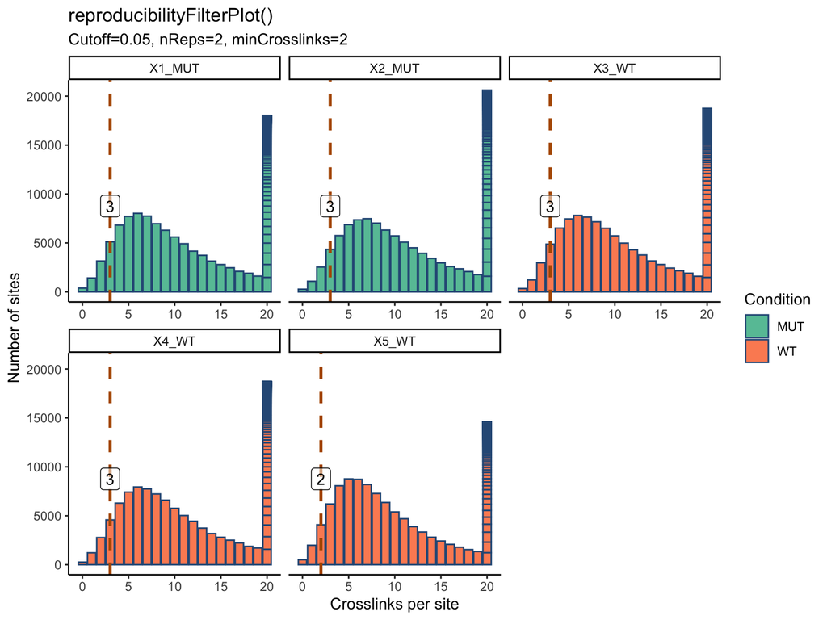

```r
reproducibilityFilterPlot(bdsMerge)
```

**Overall threshold application**

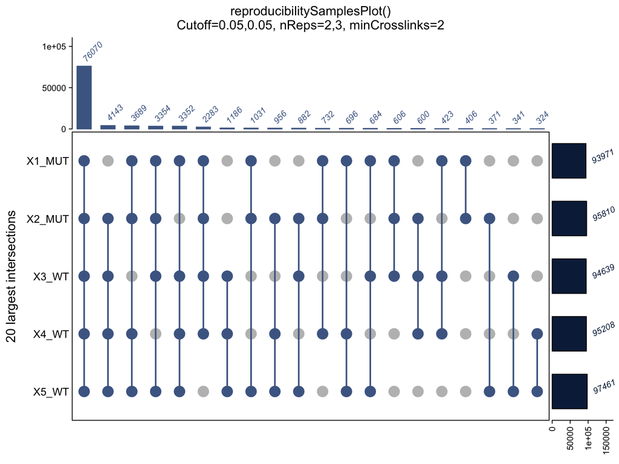

Overview of binding sites that are shared between replicates. A binding site is reproducible if supported by 2 replicates from the MUT or 3 replicates from the WT condition.

```r
reproducibilitySamplesPlot(bdsMerge)
```

**Pairwise reproducibility**

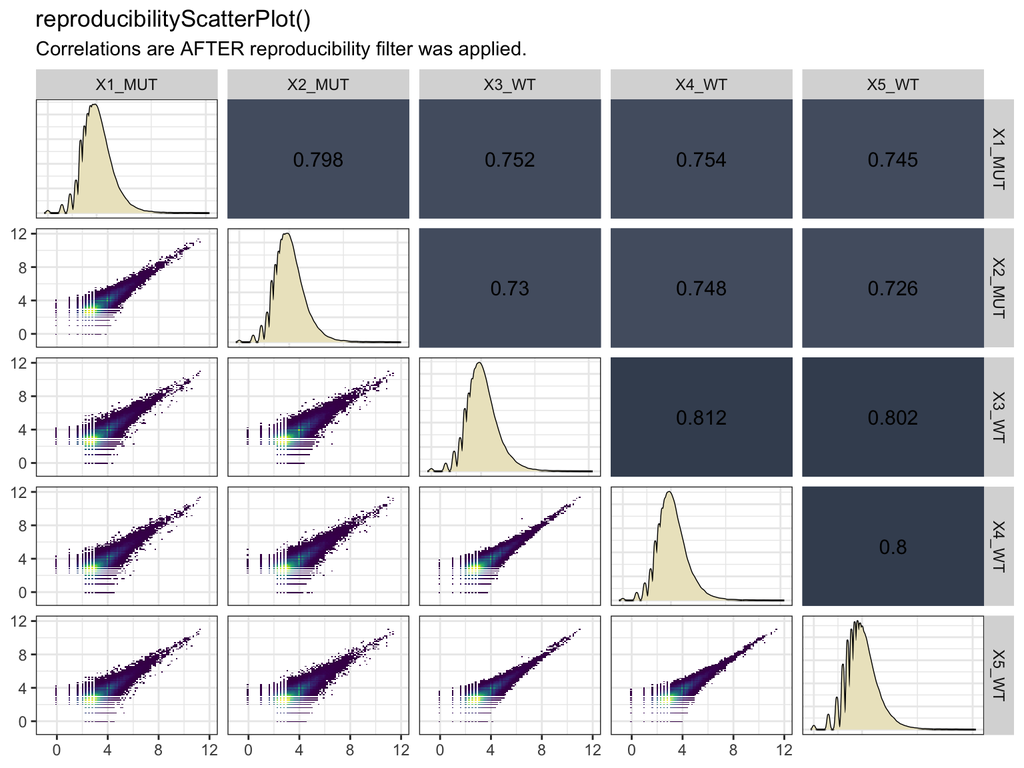

Pairwise crosslink correlation among replicates of both conditions after reproducibility filtering.

```r
reproducibilityScatterPlot(bdsMerge)
```

# 7 Genomic target identification

A major question the follow from binding site definition is the assessment of the genomic targets that SF3B1 binds to. In the following section we first assign computed binding sites to target genes and then place those that match protein coding genes on annotated transcript regions.

## 7.1 Target gene identification

```r
selectTerms = c("protein_coding", "tRNA", "lincRNA", "snRNA")
rule = unique(gns$gene_type)
rule = rule[!rule %in% selectTerms]
rule = c(selectTerms, rule)
```

```r
peaksReproducible = getRanges(bdsMerge)
targets = subsetByOverlaps(gns, peaksReproducible)
df = findOverlaps(targets, peaksReproducible) %>% as.data.frame()

# split into easy and complex cases
idxDouble = df[duplicated(df$subjectHits),]
idxSingle = df[!duplicated(df$subjectHits),]

# handle single overlap cases
peaksRepoSingle = peaksReproducible[idxSingle$subjectHits]
mcols(peaksRepoSingle)$geneType = targets$gene_type[idxSingle$queryHits]
mcols(peaksRepoSingle)$geneName = targets$gene_name[idxSingle$queryHits]
mcols(peaksRepoSingle)$geneID = targets$gene_id[idxSingle$queryHits]

# handle multi overlap cases
peaksRepoDouble = peaksReproducible[idxDouble$subjectHits]

peaksRepoDoubleCleaned = as(lapply(seq_along(peaksRepoDouble), function(x){
  currPeak = peaksRepoDouble[x]
  currTargets = subsetByOverlaps(targets, currPeak)
  nOverlaps = length(currTargets)
  # 1) take gene type as first criterion
  # -> prefer the type that is first in the `rule` list
  solution = unique(match(currTargets$gene_type, rule))
  nSolutions = length(solution)

  if (nSolutions == nOverlaps) {
    # solution successfull
    mcols(currPeak)$geneType = currTargets$gene_type[min(solution)]
    mcols(currPeak)$geneName = currTargets$gene_name[min(solution)]
    mcols(currPeak)$geneID = currTargets$gene_id[min(solution)]
  }
  if (nSolutions < nOverlaps) {
    # no solution found
    # -> Stop and return NA
    mcols(currPeak)$geneType = NA
    mcols(currPeak)$geneName = NA
    mcols(currPeak)$geneID = NA
  }
  return(currPeak)
}),"GRangesList")
peaksRepoDoubleCleaned = unlist(peaksRepoDoubleCleaned)
peaksRepoDoubleCleaned = peaksRepoDoubleCleaned[!is.na(peaksRepoDoubleCleaned$geneID)]

# assign peaks
bsGene = c(peaksRepoSingle, peaksRepoDoubleCleaned)
bsGene = sortSeqlevels(bsGene)
bsGene = sort(bsGene)
bsGene = unique(bsGene)

# assign targets
targetsGene = targets[targets$gene_id %in% bsGene$geneID]
```

Here we match binding sites with their hosting genes. Due to the degree of overlapping gene loci in the annotation some binding sites can not be unabigously mapped to a hosting gene. To recover these cases we implement a strategy that first looks for the most frequent gene annotations among overlapping cases and if these yield a tie assignment is followed by the hierarchical order: protein_coding, tRNA, lincRNA, snRNA, transcribed_unitary_pseudogene, transcribed_unprocessed_pseudogene, lncRNA, polymorphic_pseudogene, transcribed_processed_pseudogene, IG_C_gene, unprocessed_pseudogene, unitary_pseudogene, TEC, processed_pseudogene, translated_processed_pseudogene.

**Gene overlaps**

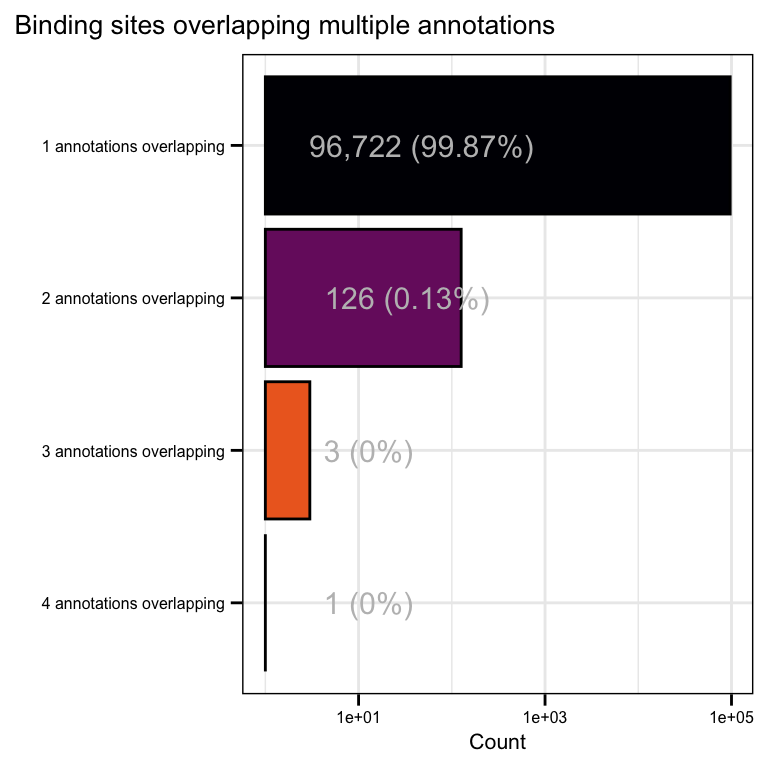

```r
# # count overlaps per peak and gene
df = findOverlaps(targets, peaksReproducible) %>% as.data.frame()
df$geneType = targets$gene_type[df$queryHits]
df = df %>%
  group_by(subjectHits) %>%
  summarise(olType = paste0(length(geneType), " annotations overlapping")) %>%
  dplyr::select(olType) %>%
  as.data.frame()

df = basicVectorToNiceDf(df)
# make plot
ggplot(df, aes(x = Type, y = Freq, fill = Type, label = labelNice)) +
    geom_col(color = "black") +
    geom_text(data = df, aes(x = Type, y = 0), size = 4, color = "grey", hjust = -.3) +
    scale_y_log10() +
    coord_flip(clip = "on", expand = TRUE) +
    theme_pub() +
    scale_fill_viridis(discrete = TRUE, direction = -1, option = "B") +
    theme(legend.position = "none") +
    labs(
        title = "Binding sites overlapping multiple annotations",
        x = "",
        y = "Count")
```

```r
# NOTE to this plot:
# -> shows how much the rule/ hierarchy affects the BS to gene assignment
# ---> many overlaps >1 means many BS will be assigned to their host gene by our rule
# -> overlaps can result in genes with different types, or genes with multiple types
```

**Targets - BS**

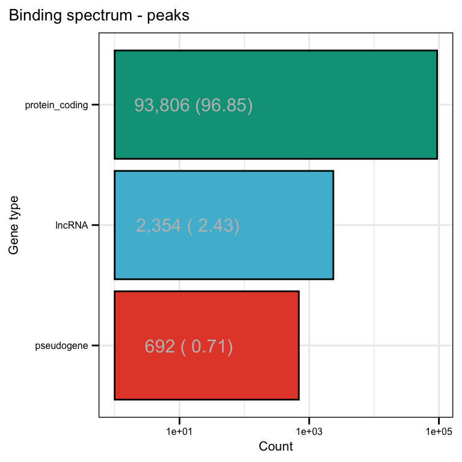

Overlap resolved binding spectrum for binding sites summarized in the top 3 most frequent gene types.

```r
df1 = data.frame(GeneType = (bsGene$geneType), type = "Peak") %>%
    mutate(GeneType = ifelse(grepl("pseudogene", GeneType), "pseudogene", GeneType)) %>%
    table() %>%
    as.data.frame() %>%
    mutate(label = paste0(format(Freq, big.mark = ",", decimal.mark = "."),
                          " (", format(round((Freq / sum(Freq))*100, digits = 2),
                                       big.mark = ",", decimal.mark = "."),")")) %>%
    mutate(GeneType = factor(GeneType, levels = c(GeneType[order(Freq)])))

ggplot(df1, aes(x = GeneType, y = Freq, fill = GeneType, label = label)) +
    geom_col(color = "black") +
    geom_text(aes(y = 0 ), size = 4, color = "grey", hjust = -.3) +
    scale_y_log10() +
    coord_flip(clip = "on", expand = TRUE) +
    scale_fill_npg() +
    theme_pub() +
    theme(legend.position = "none") +
    labs(title = "Binding spectrum - peaks",
         y = "Count",
         x = "Gene type")
```

**Targets - genes**

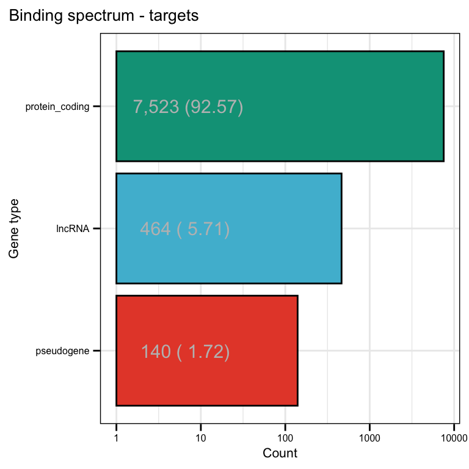

Overlap resolved binding spectrum for target genes summarized in the top 3 most frequent gene types.

```r
df2 = data.frame(GeneType = (targetsGene$gene_type), type = "Targets") %>%
    mutate(GeneType = ifelse(grepl("pseudogene", GeneType), "pseudogene", GeneType)) %>%
    table() %>%
    as.data.frame() %>%
    mutate(label = paste0(format(Freq, big.mark = ",", decimal.mark = "."),
                          " (", format(round((Freq / sum(Freq))*100, digits = 2),
                                       big.mark = ",", decimal.mark = "."),")")) %>%
    mutate(GeneType = factor(GeneType, levels = c(GeneType[order(Freq)])))

ggplot(df2, aes(x = GeneType, y = Freq, fill = GeneType, label = label)) +
  geom_col(color = "black") +
  geom_text(aes(y = 0 ), size = 4, color = "grey", hjust = -.3) +
  scale_y_log10() +
  coord_flip(clip = "on", expand = TRUE) +
  scale_fill_npg() +
  theme_pub() +
  theme(legend.position = "none") +
  labs(title = "Binding spectrum - targets",
       y = "Count",
       x = "Gene type")
```

## 7.2 Transcript region identification

```r
rule = c("intron", "cds", "utr3", "utr5")
```

To identify hosting transcript regions for each binding sites we overlap binding sites of protein-coding genes with the respective transcript regions (Introns, CDS, UTRs). Overlaps within transcripts are resolved by applying a majority vote system and ties are further resolved in a hierarchical manor with a fall back rule intron, cds, utr3, utr5 in the case of ties.

```r
targetsProt = targetsGene[targetsGene$gene_type == "protein_coding"]
bsProt = bsGene[bsGene$geneType == "protein_coding"]

# export(bsProt, "./data/bsProt.bed", format = "BED")

### count the overlap of each binidng site within each part of the gene
cdseq = cds(anno.db) %>% countOverlaps(bsProt,.)
intrns = unlist(intronsByTranscript(anno.db)) %>% countOverlaps(bsProt,.)
utrs3 = unlist(threeUTRsByTranscript(anno.db)) %>% countOverlaps(bsProt,.)
utrs5 = unlist(fiveUTRsByTranscript(anno.db)) %>% countOverlaps(bsProt,.)
count.df = data.frame(cds = cdseq, intron = intrns, utr3 = utrs3, utr5 = utrs5)

### applying the majority vote
count.df = count.df[, rule] %>%
  as.matrix %>%
  cbind.data.frame(., outside = ifelse(rowSums(count.df) == 0, 1, 0) )
names = colnames(count.df)
reg = apply(count.df, 1, function(x){ names[which.max(x)] })
### add region annotation to binding sites object
mcols(bsProt)$region = reg
```

**Transcript region overlaps**

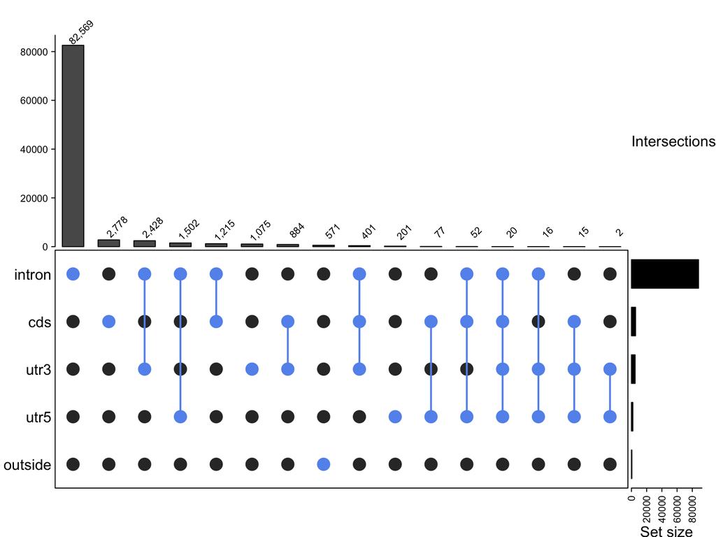

Overlap of binding sites with different transcript regions. Conflicting transcript annotations are resolved by transcript reigon.

```r
plotCountDf = count.df
plotCountDf[plotCountDf > 1] = 1
m = make_comb_mat(plotCountDf)
ha = HeatmapAnnotation(
  "Intersections" = anno_barplot(comb_size(m), border = FALSE, gp = gpar(fill = "#595959"), height = unit(6, "cm"))
)

ht = UpSet(m,
           comb_order = order(comb_size(m), decreasing = T),
            top_annotation = ha,
           comb_col = "cornflowerblue", bg_col = "white", pt_size = unit(.5, "cm") ,
           border = T, lwd = 2, bg_pt_col = "#333333"
)

ss = set_size(m)
cs = comb_size(m)
ht = draw(ht,  padding = unit(c(0, 0, 10, 0), "mm"))
od = column_order(ht)
decorate_annotation("Intersections", {
    grid.text(format(cs[od], big.mark = ",", decimal.mark = "."), x = seq_along(cs), y = unit(cs[od], "native") + unit(.1, "pt"),
        default.units = "native", just = c("left", "bottom"),
        gp = gpar(fontsize = 8, col = "black"), rot = 45)
})
```

**Transcript regions**

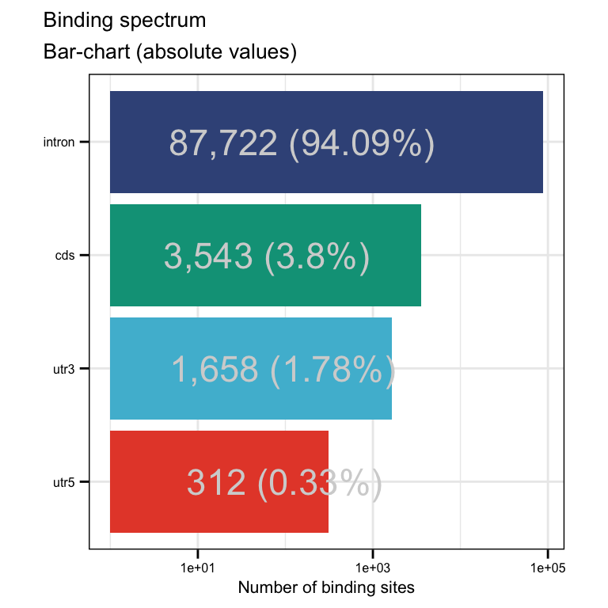

SF3B1 transcript binding spectrum. Percentage binding sites count per region.

```r
#
### remove binding sites outside of annotated regions
bsTranscript = bsProt[bsProt$region != "outside"]
targetsTranscript = targetsProt[targetsProt$gene_id %in% bsTranscript$geneID]

### make nice pie chart
df = data.frame(Type = names(table(bsTranscript$region)), Freq = as.vector(table(bsTranscript$region)))
df = df[order(df$Freq, decreasing = F),]
df$Type = factor(df$Type, levels = df$Type)
df$Frac = df$Freq / sum(df$Freq)
df$ymax = cumsum(df$Frac)
df$ymin = c(0, head(df$ymax, n=-1))
df$labPos = (df$ymax + df$ymin) / 2
df$NFrac = round(df$Frac * 100)
df$NFrac2 = round(df$Freq / sum(df$Freq), digits = 4)
df$NFracNice = df$NFrac2 * 100
df$labelNice = paste0(format(df$Freq, big.mark = ",", decimal.mark = "."), " (", df$NFracNice, "%)")
df$labelNice2 = paste0(df$Type, ": ", format(df$Freq, big.mark = ",", decimal.mark = "."), " (", df$NFracNice, "%)")

ggplot(df, aes(x = Type, y = Freq, fill = Type, label = labelNice)) +
    geom_col() +
    geom_text(data = df, aes(x = Type, y = 0), size = 6, color = "lightgrey", hjust = -.3) +
    scale_y_log10() +
    coord_flip(clip = "on", expand = TRUE) +
    scale_fill_npg() +
    theme(legend.position = "none") +
    labs(title = "Binding spectrum",
         subtitle = "Bar-chart (absolute values)",
         y = "Number of binding sites",
         x = NULL) +
    theme_pub() +
    theme(aspect.ratio = 1, legend.position = "none")
```

## 7.3 Region size normalization

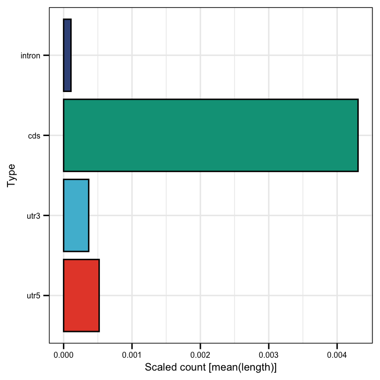

```r
cdsLen = cds(anno.db) %>%
  subsetByOverlaps(., bsTranscript) %>% width %>% sum
intrnsLen = unlist(intronsByTranscript(anno.db)) %>%
  subsetByOverlaps(., bsTranscript) %>% width %>% sum
utrs3Len = unlist(threeUTRsByTranscript(anno.db)) %>%
  subsetByOverlaps(., bsTranscript) %>% width %>% sum
utrs5Len = unlist(fiveUTRsByTranscript(anno.db)) %>%
  subsetByOverlaps(., bsTranscript) %>% width %>% sum
lenDfSum = data.frame(lenSum = c(cdsLen, intrnsLen, utrs3Len, utrs5Len))


df = data.frame(type = names(table(bsTranscript$region)), val = as.vector(table(bsTranscript$region)))
df = cbind(df, lenDfSum)
df = df[order(df$val, decreasing = F),]
df$type = factor(df$type, levels = df$type)

ggplot(df, aes(x = type, y = val/lenSum, fill = type)) +
  geom_col(color = "black") +
  scale_fill_npg() +
  coord_flip() +
  theme_pub() +
  xlab("Type") +
  ylab("Scaled count [mean(length)]") +
  theme(legend.position = "none")
```

# 8 Tables and numbers

```r
### ============================================================================
### Numbers
### ----------------------------------------------------------------------------
###

peaksInitial = peaksInitial[!seqnames(peaksInitial) %in% "chrY"]
b1 = setRanges(bds, peaksInitial)
c1 = coverageOverRanges(b1, returnOptions = "merge_positions_keep_replicates") %>% mcols() %>% as.matrix()

peaksFiltered = peaksFiltered[!seqnames(peaksFiltered) %in% "chrY"]
b2 = setRanges(bds, peaksFiltered)
c2 = coverageOverRanges(b2, returnOptions = "merge_positions_keep_replicates") %>% mcols() %>% as.matrix()

b25 = setRanges(bds, peaksFilteredPerGene)
c25 = coverageOverRanges(b25, returnOptions = "merge_positions_keep_replicates") %>% mcols() %>% as.matrix()

b3 = setRanges(bds, peaksProcessed)
c3 = coverageOverRanges(b3, returnOptions = "merge_positions_keep_replicates") %>% mcols() %>% as.matrix()

b4 = setRanges(bds, peaksReproducible)
c4 = coverageOverRanges(b4, returnOptions = "merge_positions_keep_replicates") %>% mcols() %>% as.matrix()

b5 = setRanges(bds, bsGene)
c5 = coverageOverRanges(b5, returnOptions = "merge_positions_keep_replicates") %>% mcols() %>% as.matrix()

b6 = setRanges(bds, bsProt)
c6 = coverageOverRanges(b6, returnOptions = "merge_positions_keep_replicates") %>% mcols() %>% as.matrix()

b7 = setRanges(bds, bsTranscript)
c7 = coverageOverRanges(b7, returnOptions = "merge_positions_keep_replicates") %>% mcols() %>% as.matrix()

df = data.frame(nPeaks = c(length(peaksInitial),
                           length(peaksFiltered),
                           length(peaksFilteredPerGene),
                           length(peaksProcessed),
                           length(peaksReproducible),
                           length(bsGene),
                           length(bsProt),
                           length(bsTranscript)),
                nTargets = c(length(subsetByOverlaps(gns, peaksInitial)),
                             length(subsetByOverlaps(gns, peaksFiltered)),
                             length(subsetByOverlaps(gns, peaksFilteredPerGene)),
                             length(subsetByOverlaps(gns, peaksProcessed)),
                             length(subsetByOverlaps(gns, peaksReproducible)),
                             length(unique(bsGene$geneID)),
                             length(unique(bsProt$geneID)),
                             length(unique(bsTranscript$geneID)) ),
                nXlinksMUT = c(sum(dplyr::select(as.data.frame(c1), ends_with("MUT"))),
                               sum(dplyr::select(as.data.frame(c2), ends_with("MUT"))),
                               sum(dplyr::select(as.data.frame(c25), ends_with("MUT"))),
                               sum(dplyr::select(as.data.frame(c3), ends_with("MUT"))),
                               sum(dplyr::select(as.data.frame(c4), ends_with("MUT"))),
                               sum(dplyr::select(as.data.frame(c5), ends_with("MUT"))),
                               sum(dplyr::select(as.data.frame(c6), ends_with("MUT"))),
                               sum(dplyr::select(as.data.frame(c7), ends_with("MUT")))
                ),
                nXlinksWT = c(sum(dplyr::select(as.data.frame(c1), ends_with("WT"))),
                              sum(dplyr::select(as.data.frame(c2), ends_with("WT"))),
                              sum(dplyr::select(as.data.frame(c25), ends_with("WT"))),
                              sum(dplyr::select(as.data.frame(c3), ends_with("WT"))),
                              sum(dplyr::select(as.data.frame(c4), ends_with("WT"))),
                              sum(dplyr::select(as.data.frame(c5), ends_with("WT"))),
                              sum(dplyr::select(as.data.frame(c6), ends_with("WT"))),
                              sum(dplyr::select(as.data.frame(c7), ends_with("WT")))
                )
)

df = format(df, big.mark = ",", decimal.mark = ".")
rownames(df) = c("CLS - PureCLIP", "CLS - Global filter", "CLS - Gene level filter", "BS - Merged", "BS - Reproducible", "BS - Gene", "BS - Protein", "BS - Transcript")
colnames(df) = c("CLS/BS (N)", "Targets (N)", "Xlinks (MUT)", "Xlinks (WT)")

kable(df, caption = "Processing Overview. CLS = Crosslink sites/ BS = Binding sites") %>%
  kable_styling("striped") %>%
  scroll_box(width = "100%")
```

Processing Overview. CLS = Crosslink sites/ BS = Binding sites

|  | CLS/BS (N) | Targets (N) | Xlinks (MUT) | Xlinks (WT) |
| --- | --- | --- | --- | --- |
| CLS - PureCLIP | 2,452,405 | 10,899 | 9,139,819 | 12,921,765 |
| CLS - Global filter | 2,329,784 | 10,892 | 8,981,133 | 12,685,840 |
| CLS - Gene level filter | 438,570 | 10,458 | 4,095,895 | 5,668,280 |
| BS - Merged | 104,034 | 8,826 | 3,196,681 | 4,456,865 |
| BS - Reproducible | 96,852 | 8,186 | 3,140,187 | 4,367,252 |
| BS - Gene | 96,852 | 8,127 | 3,140,187 | 4,367,252 |
| BS - Protein | 93,806 | 7,523 | 2,860,559 | 4,038,548 |
| BS - Transcript | 93,235 | 7,513 | 2,847,185 | 4,020,148 |

```r
### ============================================================================
### xlinks in bs per replicate per filter step
### ----------------------------------------------------------------------------
###
df = data.frame(
  x1 = colSums(c1),
  x2 = colSums(c2),
  x25 = colSums(c25),
  x3 = colSums(c3),
  x4 = colSums(c4),
  x5 = colSums(c5),
  x6 = colSums(c6),
  x7 = colSums(c7)
)
df = format(df, big.mark = ".", decimal.mark = ",")
colnames(df) = c("CLS - PureCLIP", "CLS - Global filter", "CLS - Gene level filter", "BS - Merged", "BS - Reproducible", "BS - Gene", "BS - Protein", "BS - Transcript")
rownames(df) = c("S1 - MUT", "S2 - MUT", "S3 - WT", "S4 - WT", "S5 - WT")
df = t(df)

kable(df, caption = "Xlinks in peaks/bs per replicate per filtering step") %>%
  kable_styling("striped") %>%
  scroll_box(width = "100%")
```

Xlinks in peaks/bs per replicate per filtering step

|  | S1 - MUT | S2 - MUT | S3 - WT | S4 - WT | S5 - WT |
| --- | --- | --- | --- | --- | --- |
| CLS - PureCLIP | 4.406.096 | 4.733.723 | 4.421.934 | 4.497.462 | 4.002.369 |
| CLS - Global filter | 4.327.379 | 4.653.754 | 4.342.396 | 4.416.946 | 3.926.498 |
| CLS - Gene level filter | 1.945.206 | 2.150.689 | 1.969.342 | 1.994.887 | 1.704.051 |
| BS - Merged | 1.530.741 | 1.665.940 | 1.551.904 | 1.569.061 | 1.335.900 |
| BS - Reproducible | 1.505.501 | 1.634.686 | 1.521.256 | 1.538.149 | 1.307.847 |
| BS - Gene | 1.505.501 | 1.634.686 | 1.521.256 | 1.538.149 | 1.307.847 |
| BS - Protein | 1.370.501 | 1.490.058 | 1.412.684 | 1.418.379 | 1.207.485 |
| BS - Transcript | 1.364.086 | 1.483.099 | 1.406.247 | 1.411.882 | 1.202.019 |

# 9 Binding patterns

## 9.1 Flanking regions next to exons

```r
exn = exons(anno.db)
export(granges(exn), "./data/exn.bed", format = "BED")
# define flanking regsions
leftEdge = flank(exn, width = 100, start = TRUE)
export(granges(leftEdge), "./data/leftEdge.bed", format = "BED")
rightEdge = flank(exn, width = 100, start = FALSE)
export(granges(rightEdge), "./data/rightEdge.bed", format = "BED")
```

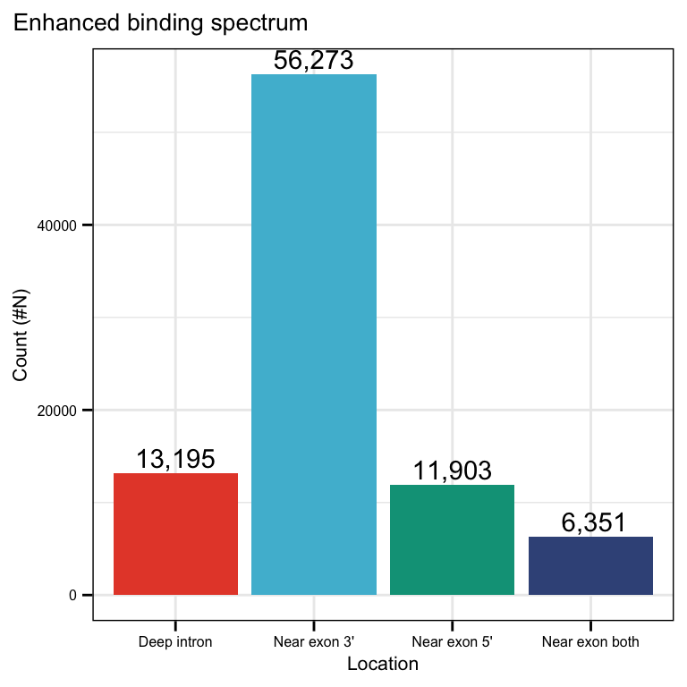

Binding sites in introns split by near exon (within 100nt from splice sites) and deep-intronic regions

```r
# split BS in left /right
# splti BS in left/ right/ both

# split right side
rightOLS = findOverlaps(bsTranscript, leftEdge) %>% as.data.frame()
rightIDX = unique(rightOLS$queryHits)

# split left side
leftOLS = findOverlaps(bsTranscript, rightEdge) %>% as.data.frame()
leftIDX = unique(leftOLS$queryHits)

# make unique assignment
bothSidesIDX = rightIDX[rightIDX %in% leftIDX]
rightIDX = rightIDX[! rightIDX %in% bothSidesIDX]
leftIDX = leftIDX[! leftIDX %in% bothSidesIDX]

# split deep intronic
deepIntronIDX = 1:length(bsTranscript)
deepIntronIDX = deepIntronIDX[! deepIntronIDX %in% c(rightIDX, leftIDX, bothSidesIDX)]

# annotate ranges
rightBS = bsTranscript[rightIDX]
leftBS = bsTranscript[leftIDX]
bothSidesBS = bsTranscript[bothSidesIDX]
deepIntronBS = bsTranscript[deepIntronIDX]
mcols(rightBS)$intronLocation = "Near exon 3'"
mcols(leftBS)$intronLocation = "Near exon 5'"
mcols(bothSidesBS)$intronLocation = "Near exon both"
mcols(deepIntronBS)$intronLocation = "Deep intron"

bsTranscript = c(rightBS, leftBS, bothSidesBS, deepIntronBS)
bsTranscript = sortSeqlevels(bsTranscript)
bsTranscript = sort(bsTranscript)
mcols(bsTranscript)$intronLocation = ifelse(bsTranscript$region != "intron", NA, bsTranscript$intronLocation)

df = data.frame(intronLocation = bsTranscript$intronLocation) %>%
    table() %>%
    as.data.frame()

ggplot(df, aes(x = intronLocation, y = Freq, fill = intronLocation)) +
    geom_col() +
    geom_text(aes(label = myFormat(Freq)), vjust = -0.3) +
    scale_fill_npg() +
    theme_pub() +
    theme(legend.position = "none") +
    labs(
        title = "Enhanced binding spectrum",
         y = "Count (#N)",
         x = "Location")
```

```r
exn = exons(anno.db, columns = c("exon_id", "gene_id", "exon_name"))
names(exn) = exn$exon_id
export(granges(exn), "./data/exn.bed", format = "BED")

exnBeforeIdx = follow(bsTranscript, exn)
exnBeforeIdx[is.na(exnBeforeIdx)] = 557990
exnBeforeDist = distance(bsTranscript, exn[exnBeforeIdx])

exnAfterIdx = precede(bsTranscript, exn)
exnAfterIdx[is.na(exnAfterIdx)] = 557990
exnAfterDist = distance(bsTranscript, exn[exnAfterIdx])


distDf = data.frame(distBefore = exnBeforeDist, distAfter = exnAfterDist) %>%
    mutate(side = ifelse(distBefore < distAfter, "before", "after")) %>%
    mutate(distToExon = ifelse(distBefore < distAfter, distBefore, distAfter)) %>%
    mutate(positionTag = ifelse(distToExon > 100, "deep intron", "near exon")) %>%
    mutate(exonID = ifelse(side == "after", exnAfterIdx, exnBeforeIdx)) %>%
    mutate(bsID = names(bsTranscript)) %>%
    mutate(exonName = exn$exon_name[exonID]) %>%
    select(positionTag, side, distToExon, exonID, bsID, exonName)

mcols(bsTranscript) = cbind(mcols(bsTranscript), distDf)

### export
export(bsTranscript, "./data/bsTranscript.bed", format = "BED")
save(bsTranscript, file = "./data/bsTranscript.rda")
```

## 9.2 Distances

To find patterns in binding site spacing, we calculated the distance from each binding sites to its nearest neighbor.

**Zoom-Out**

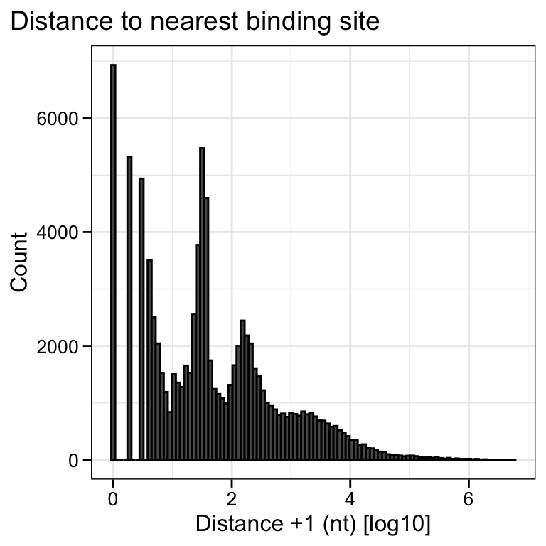

Distance from each binding site to the next closest neighbor.

```r
dist = distanceToNearest(bsTranscript) %>% as.data.frame()
bsTranscript$dist = dist$distance
ggplot(dist, aes(x = log10(distance+1))) +
  geom_histogram(bins = 100, color = "black") +
  theme_nice() +
  labs(
    title = "Distance to nearest binding site",
    x = "Distance +1 (nt) [log10]",
    y = "Count")
```

**Zoom-In**

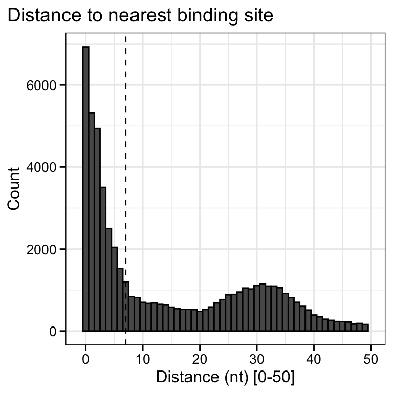

Distance from each binding site to the next closest neighbor in a range of 50 nt.

```r
ggplot(dist, aes(x = distance)) +
  geom_histogram(binwidth = 1, color = "black") +
  xlim(-1,50) +
  theme_nice() +
  labs(
    title = "Distance to nearest binding site",
    x = "Distance (nt) [0-50]",
    y = "Count") +
  geom_vline(xintercept = 7, linetype = "dashed")
```